# MA615 Twitter Data Mining Projct

Smart Home

Mengyun Li

Dec 4, 2017

```
## [1] "Using direct authentication"
```

# 1. Introduction: What is Smart Home ?

Smart Home is building automation for a home. It involves the control and automation of lighting, heating (such as smart thermostats), ventilation, air conditioning (HVAC), and security, as well as home appliances such as washer/dryers, ovens or refrigerators/freezers. Wi-Fi is often used for remote monitoring and control. Home devices, when remotely monitored and controlled via the Internet, are an important constituent of the Internet of Things.

This analysis compares two smart home product I like most, Google Home Mini and Echo Dot. Through Google Home I can get hands-free help from the Google Assistant. Get answers, play songs, tackle your day, enjoy your entertainment and control your smart home with just my voice.

[figure not shown]

Amazon Echo (shortened and referred to as Echo) is a brand of smart speakers developed by Amazon.com. The devices connect to the voice-controlled intelligent personal assistant service Alexa, which responds to the name “Alexa”. The device is capable of voice interaction, music playback, making to-do lists, setting alarms, streaming podcasts, playing audiobooks, and providing weather, traffic and other real-time information. It can also control several smart devices using itself as a home automation hub.

[figure not shown]

For more information, visit product webpage. Google home: https://store.google.com/product/google_home Echo Dot:https://www.amazon.com/Amazon-Echo-Dot-Previous-Generation/b?ie=UTF8&node=14047587011

[output not shown]

# 2. Word cloud - A helicopter View

### “Home Smart”

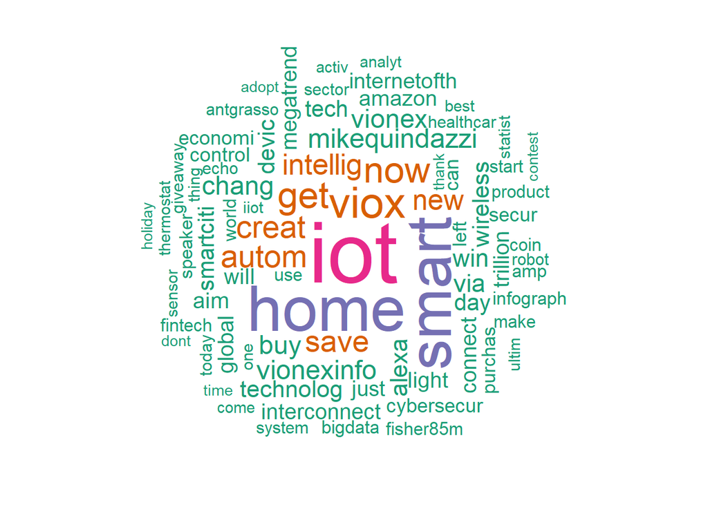

### “Google Home”

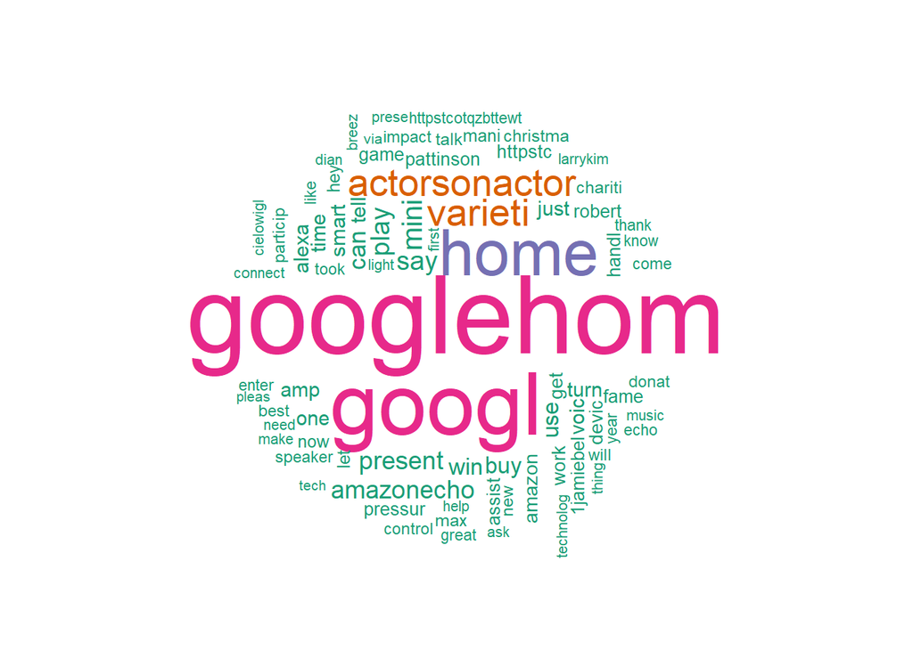

### “Echo Dot”

[figure not shown]

# 3. Sentiment Analysis

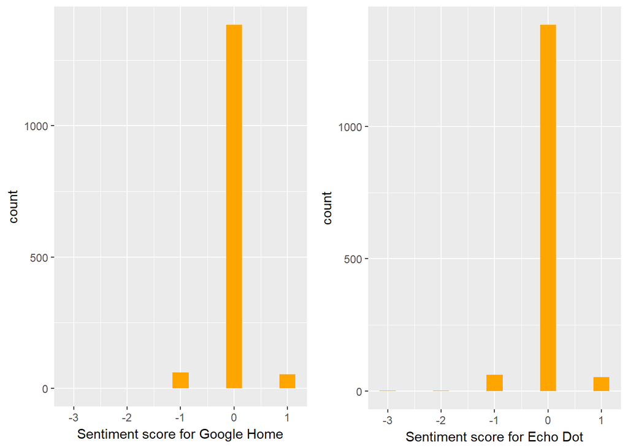

This is not a efficient analysis since most of comments have score zero. This shows that most of tweets didn’t have any positive or negative comment.

# 4. Time Line

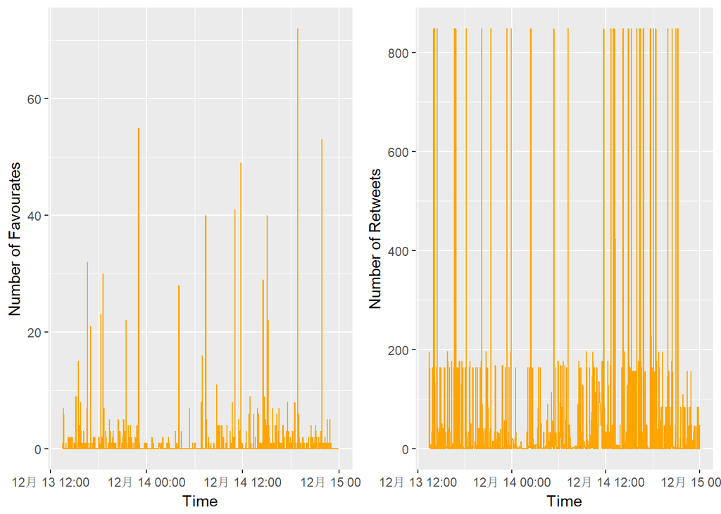

# 5. Map

### Location of tweets related to the topic “Smart Home” created.

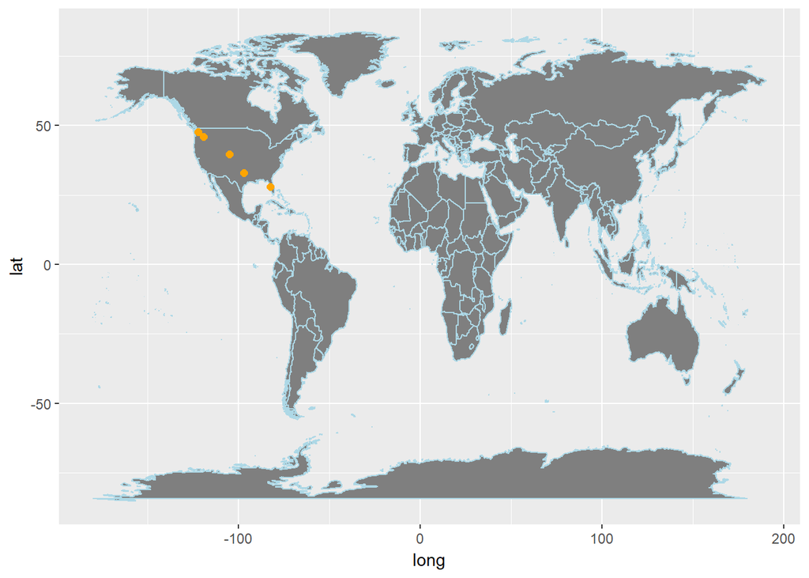

The location of the tweets in the topic “Smart Home” created are most in United States.